# Valtion hankintojen maantieteeliset erot, toimittajien keskittyneisyys ja luotettavuus

## Projektin aineisto ja analyysin kuvaus

### Aineisto

Tässä projektissa käytettävä aineisto koostuu kahdesta Excel-tiedostosta:

1. **Valtion ostolaskut** -tiedosto, joka sisältää seuraavat sarakkeet:
   - `lasku_id`
   - `tili`
   - `tiliointisumma`
   - `tositepvm`
   - `toimittaja_y_tunnus`
   - `toimittaja_nimi`
   - `hankintayksikko_tunnus`
   - `hankintayksikko`
   - `ylaorganisaatio_tunnus`
   - `ylaorganisaatio`
   - `sektori`
   - `tuote_palveluryhma`
   - `hankintakategoria`
2. **Toimittajatiedot** -tiedosto, joka sisältää seuraavat sarakkeet:
   - `Yrityksen nimi`
   - `Kotipaikka`
   - `Y-tunnus`
   - `Rating Alfa`
   - `Vastuullisuustarkastus`
   - `Liikevaihto tuhat €`
   - `LV Vuosi`
   - `Muutos`
   - `Bruttotulos tuhat €`
   - `BT Vuosi`
   - `Muutos.1`
   - `Liikevoitto tuhat €`
   - `Omavaraisuus`

### Tiedon esikäsittely

**Valtion ostolaskut** -taulukossa sarakkeessa `tiliointisumma` oli **121 negatiivista arvoa**. Nämä poistettiin, jotta ne eivät vaikuttaisi analyysin tuloksiin.

### Projektin analyysin tavoitteet

Tässä projektissa tarkastellaan valtion hankintoja seuraavista näkökulmista:

1. **Hankintojen riippuvuus toimittajien määrästä ja keskittyneisyydestä:**  
   Tutkitaan Herfindahl-Hirschman-indeksin (HHI) avulla, miten keskittyneitä hankinnat ovat yksittäisiin toimittajiin.
2. **Hankintojen erot toimittajien kotipaikan perusteella:**  
   Selvitetään, missä määrin toimittajien kotipaikasta riippuu, mitkä palvelut sisältyvät hankitoihin, ja paljonko hankinnat maksavat.
3. **Toimittajien luotettavuus:**  
   Analysoidaan toimittajien taloudellisia indikaattoreita, kuten liikevaihto, omavaraisuus ja vastuullisuustarkastus, hankintojen näkökulmasta.

## Toimittajien keskittyneisyys

Tässä osiossa tarkistetaan moneltako toimittajista valtion yksiköt hankkivat palveluita. Ensin tarkistetaan toimittajien keskittyneisyyttä **hankitayksikköiden** tasolla ja sitten siirretään yllemmälle tasolle eli **yläorganisaation** tasolle, jolla hankintayksikot yhditetty hallintoaloiksi. Keskittyneisyyttä arvioidaan sekä tarkistamalla *toimittajien määrää ja osuutta* että käyttämällä *Herfindahl-Hirschman-indeksiä* (HHI). HHI on yleisesti käytetty mittari markkinoiden keskittyneisyyden arvioimiseen. Kilpailuviranomaiset, kuten Euroopan komissio, Yhdysvaltain oikeusministeriö (DOJ) ja liittovaltion kauppakomissio (FTC), käyttävät HHI:tä päätöksenteossa.

### Arviointi hankintayksikköjen tasolla

#### HHI indeksin avulla

Tässä analyysissa **Herfindahl-Hirschman-indeksi (HHI)** laskettiin hankintayksiköille niiden toimittajien osalta, mikä auttaa tunnistamaan, kuinka keskittynyttä ostotoiminta on. Tämä on erityisen tärkeää, koska korkea HHI-arvo voi viitata *riippuvuuteen yhdestä tai muutamasta toimittajasta*. Tällainen riippuvuus voi johtaa riskeihin, kuten hintojen nousuun tai toimituskatkoksiin.

HHI lasketaan toimittajakohtaisten markkinaosuuksien neliöiden summana, ja sen arvo vaihtelee nollan ja yhden välillä. Nolla tarkoittaa täydellistä kilpailua, kun taas yksi tarkoittaa, että yksi toimittaja hallitsee täysin markkinoita. Käytännössä HHI:n tuloksia tulkitaan seuraavasti:

- **Alle 0,10:** Matala keskittyminen – kilpailu on terveellä pohjalla.
- **0,10–0,18:** Kohtalainen keskittyminen – kilpailun vähenemisen riski.
- **Yli 0,18:** Korkea keskittyminen – riski monopolisoitumisesta tai vahvasta riippuvuudesta.

**Tämä viittaa siihen, että yli 70 % hankintayksiköistä on voimakkaasti riippuvaisia yhdestä tai muutamasta toimittajasta.** Tämä keskittyminen voi johtaa merkittäviin riskeihin, kuten kustannusten kasvuun tai toimitusvarmuuden heikkenemiseen.

Analyysissa korostui muutama tärkeä huomio. Ensinnäkin hankintayksiköiden tulisi **monipuolistaa toimittajaverkostoaan**, jotta riippuvuus yksittäisistä toimittajista vähenisi. Toiseksi korkea HHI voi joissakin tapauksissa olla perusteltua, erityisesti silloin, kun toimittajat ovat erikoistuneita tiettyihin palveluihin tai tuotteisiin. Lopuksi on tärkeää **edistää läpinäkyvyyttä hankintojen keskittymisessä**, sillä tämä voi lisätä keskustelua julkisten varojen käytön tehokkuudesta ja oikeudenmukaisuudesta.

*Tällainen analyysi* nostaa esiin myös laajempia kysymyksiä, kuten:

- Hyödynnetäänkö julkisessa hankintatoimessa kilpailutuksen koko potentiaalia?
- Mitä hyötyjä ja riskejä liittyy hankintojen keskittymiseen?
- Voisiko kilpailun lisääminen tuottaa merkittäviä hyötyjä veronmaksajille?

**Näihin kysymyksiin vastaaminen voi auttaa kehittämään parempia käytäntöjä ja vähentämään keskittymisen aiheuttamia riskejä.** Tämä analyysi palvelee sekä päätöksentekijöitä että kansalaisia, jotka ovat kiinnostuneita julkisten varojen käytöstä ja kilpailutuksen toimivuudesta.

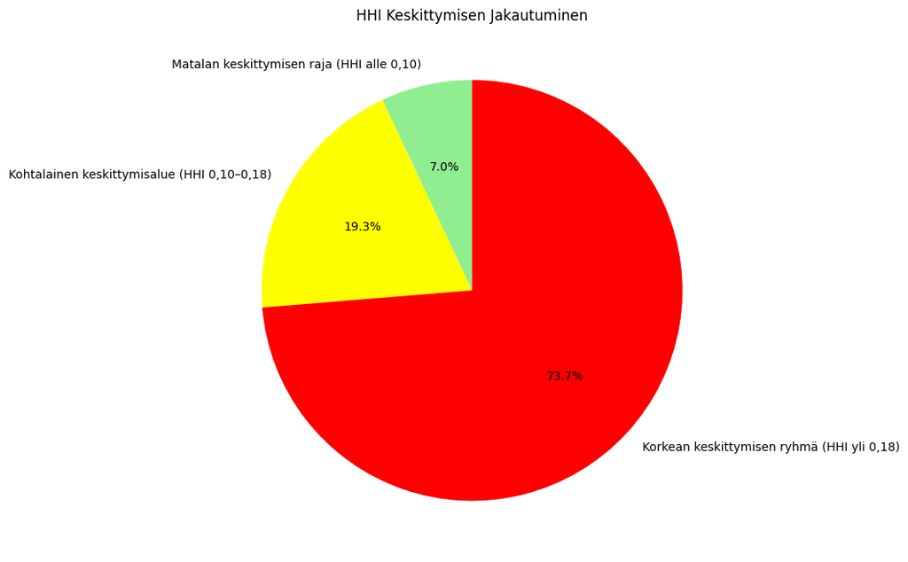

|  | hankintayksikkö | HHI |
| --- | --- | --- |
| 0 | Sosiaali- ja terveysalan lupa- ja valvontavirasto | 0.773945 |
| 1 | Pelastusopisto | 0.611698 |
| 2 | Ulkopoliittinen instituutti | 0.604944 |
| 3 | Rikosseuraamuslaitos | 0.601823 |
| 4 | Liikenne- ja viestintäministeriö | 0.564288 |
| 5 | Valtioneuvoston kanslia | 0.526197 |
| 6 | Kansallisarkisto | 0.519450 |
| 7 | Tulli | 0.513106 |
| 8 | Syyttäjälaitos | 0.509255 |
| 9 | Ulosottolaitos | 0.504072 |
| 10 | Sosiaaliturva-asioiden muutoksenhakulautakunta | 0.493149 |
| 11 | Tuomioistuinlaitos | 0.437758 |
| 12 | Patentti- ja rekisterihallitus | 0.409491 |
| 13 | Oikeusministeriö | 0.408528 |
| 14 | Museovirasto | 0.406333 |
| 15 | Energiavirasto | 0.399888 |
| 16 | Valtiovarainministeriö | 0.369483 |
| 17 | Valtiokonttori | 0.361171 |
| 18 | Tilastokeskus | 0.353097 |
| 19 | ELY-keskusten ja TE-toimistojen kehittämis- ja hallintokeskus | 0.336469 |
| 20 | Innovaatiorahoituskeskus Business Finland | 0.333555 |
| 21 | Lääkealan turvallisuus- ja kehittämiskeskus | 0.331815 |
| 22 | Suomen ympäristökeskus | 0.325805 |
| 23 | Opetushallitus | 0.325190 |
| 24 | Rahoitusvakausvirasto | 0.319127 |
| 25 | Hätäkeskuslaitos | 0.312567 |
| 26 | Valtiontalouden tarkastusvirasto | 0.310162 |
| 27 | Kilpailu- ja kuluttajavirasto | 0.308262 |
| 28 | Ruokavirasto | 0.307537 |
| 29 | Geologian tutkimuskeskus | 0.306590 |
| 30 | Suomen Akatemia | 0.303756 |
| 31 | Verohallinto | 0.293387 |
| 32 | Sisäministeriö | 0.291932 |
| 33 | Maa- ja metsätalousministeriö | 0.263248 |
| 34 | Sosiaali- ja terveysministeriö | 0.259615 |
| 35 | Etelä-Suomen aluehallintovirasto | 0.259189 |
| 36 | Turvallisuus- ja kemikaalivirasto | 0.247553 |
| 37 | Työ- ja elinkeinoministeriö | 0.230406 |
| 38 | Maahanmuuttovirasto | 0.219853 |
| 39 | Valtion talous- ja henkilöstöhallinnon palvelukeskus | 0.219400 |
| 40 | Valtion taloudellinen tutkimuskeskus | 0.209829 |
| 41 | Oikeusrekisterikeskus | 0.204699 |
| 42 | Tasavallan presidentin kanslia | 0.186412 |
| 43 | Säteilyturvakeskus | 0.173005 |
| 44 | Asumisen rahoitus- ja kehittämiskeskus | 0.170610 |
| 45 | Terveyden ja hyvinvoinnin laitos | 0.151667 |
| 46 | Suomenlinnan hoitokunta | 0.148059 |
| 47 | Maanmittauslaitos | 0.147594 |
| 48 | Opetus- ja kulttuuriministeriö | 0.142455 |
| 49 | Ympäristöministeriö | 0.141807 |
| 50 | Valtion tieto- ja viestintätekniikkakeskus Valtori | 0.116437 |
| 51 | Väylävirasto | 0.106790 |
| 52 | Ilmatieteen laitos | 0.105679 |
| 53 | Digi- ja väestötietovirasto | 0.100091 |
| 54 | Eduskunta | 0.099886 |
| 55 | Luonnonvarakeskus | 0.096966 |
| 56 | Ulkoministeriö | 0.089896 |
| 57 | Liikenne- ja viestintävirasto Traficom | 0.081421 |

#### Toimittajien määrien ja osuuksien avulla

Näyttää siltä, että määrä yksinään ei ole ratkaiseva tekijä, vaan hankintojen jakautuminen toimittajien kesken vaikuttaa suuresti HHI-indeksiin. Esimerkiksi:

- **ELY-keskusten ja TE-toimistojen kehittämis- ja hallintokeskuksella** on 366 toimittajaa, mikä on 12,4 % kaikista toimittajista. Tästä huolimatta sen HHI on **yli 0,18**, mikä viittaa korkeaan keskittymiseen. Tämä todennäköisesti johtuu siitä, että osa toimittajista saa huomattavan suuria sopimuksia, kun taas monet muut jäävät pienemmille osuuksille.
- **Liikenne- ja viestintävirasto Traficomilla** (64 toimittajaa, 2,2 %) ja **Eduskunnalla** (61 toimittajaa, 2,1 %) on vähemmän toimittajia kuin ELY-keskusten ja TE-toimistojen kehittämis- ja hallintokeskuksella, mutta niiden HHI on **alle 0,1**, mikä tarkoittaa matalaa keskittymistä. Molemmat yksiköt ovat jakaneet hankintansa tasaisemmin useille toimittajille.
- **Vähiten toimittajia:**
  - **Sosiaaliturva-asioiden muutoksenhakulautakunta** on vain 3 toimittajaa, mikä on pienin määrä yksiköistä ja vastaa **0,1 %** kaikista toimittajista. Mutta sillä ei ole kaikista pahin HHI indeksi.

Johtopäätös: Pelkkä toimittajien määrä ei riitä riskien arviointiin  
Toimittajien määrä yksinään ei määrittele hankintayksikön riskiä. Sen sijaan keskittymisriskit (HHI) riippuvat siitä, kuinka tasaisesti hankinnat jakautuvat toimittajien kesken.

- Yksiköillä, joilla on suuri määrä toimittajia, voi silti olla korkea HHI, jos muutamat toimittajat saavat merkittävän osan sopimuksista.
- Yksiköillä, joilla on vähemmän toimittajia, voi puolestaan olla matala HHI, jos hankinnat jakautuvat tasaisesti.

Riskinhallinnan näkökulma  
Hankintayksiköiden tulisi kiinnittää huomiota paitsi toimittajien määrään myös hankintojen jakautumiseen. Erityisesti yksiköiden, jotka ovat HHI-riskivyöhykkeellä, tulisi arvioida strategioitaan monipuolistamalla toimittajaverkostoaan ja vähentämällä riippuvuutta yksittäisistä toimittajista.

Esimerkkejä jatkokysymyksille:

|  | hankintayksikkö | toimittajien määrä | toimittajien määrän osuus % |
| --- | --- | --- | --- |
| 2 | ELY-keskusten ja TE-toimistojen kehittämis- ja hallintokeskus | 366 | 12.4 |
| 56 | Väylävirasto | 190 | 6.5 |
| 39 | Terveyden ja hyvinvoinnin laitos | 154 | 5.2 |
| 27 | Rikosseuraamuslaitos | 147 | 5.0 |
| 14 | Luonnonvarakeskus | 119 | 4.0 |
| 42 | Tuomioistuinlaitos | 108 | 3.7 |
| 23 | Opetushallitus | 107 | 3.6 |
| 28 | Ruokavirasto | 88 | 3.0 |
| 8 | Ilmatieteen laitos | 87 | 3.0 |
| 18 | Maanmittauslaitos | 85 | 2.9 |
| 17 | Maahanmuuttovirasto | 82 | 2.8 |
| 20 | Oikeusministeriö | 77 | 2.6 |
| 5 | Etelä-Suomen aluehallintovirasto | 73 | 2.5 |
| 41 | Tulli | 69 | 2.3 |
| 45 | Ulkoministeriö | 67 | 2.3 |
| 13 | Liikenne- ja viestintävirasto Traficom | 64 | 2.2 |
| 22 | Opetus- ja kulttuuriministeriö | 63 | 2.1 |
| 34 | Suomen ympäristökeskus | 62 | 2.1 |
| 3 | Eduskunta | 61 | 2.1 |
| 51 | Valtion tieto- ja viestintätekniikkakeskus Valtori | 54 | 1.8 |
| 55 | Verohallinto | 47 | 1.6 |
| 52 | Valtioneuvoston kanslia | 46 | 1.6 |
| 47 | Ulosottolaitos | 44 | 1.5 |
| 6 | Geologian tutkimuskeskus | 41 | 1.4 |
| 1 | Digi- ja väestötietovirasto | 38 | 1.3 |
| 19 | Museovirasto | 38 | 1.3 |
| 37 | Säteilyturvakeskus | 37 | 1.3 |
| 25 | Pelastusopisto | 33 | 1.1 |
| 35 | Suomenlinnan hoitokunta | 28 | 1.0 |
| 7 | Hätäkeskuslaitos | 26 | 0.9 |
| 29 | Sisäministeriö | 26 | 0.9 |
| 10 | Kansallisarkisto | 25 | 0.9 |
| 43 | Turvallisuus- ja kemikaalivirasto | 25 | 0.9 |
| 38 | Tasavallan presidentin kanslia | 25 | 0.9 |
| 21 | Oikeusrekisterikeskus | 24 | 0.8 |
| 36 | Syyttäjälaitos | 24 | 0.8 |
| 24 | Patentti- ja rekisterihallitus | 24 | 0.8 |
| 50 | Valtion talous- ja henkilöstöhallinnon palvelukeskus | 22 | 0.7 |
| 31 | Sosiaali- ja terveysministeriö | 22 | 0.7 |
| 48 | Valtiokonttori | 22 | 0.7 |
| 16 | Maa- ja metsätalousministeriö | 22 | 0.7 |
| 15 | Lääkealan turvallisuus- ja kehittämiskeskus | 19 | 0.6 |
| 40 | Tilastokeskus | 17 | 0.6 |
| 57 | Ympäristöministeriö | 16 | 0.5 |
| 30 | Sosiaali- ja terveysalan lupa- ja valvontavirasto | 16 | 0.5 |
| 53 | Valtiontalouden tarkastusvirasto | 14 | 0.5 |
| 44 | Työ- ja elinkeinoministeriö | 12 | 0.4 |
| 9 | Innovaatiorahoituskeskus Business Finland | 11 | 0.4 |
| 12 | Liikenne- ja viestintäministeriö | 11 | 0.4 |
| 0 | Asumisen rahoitus- ja kehittämiskeskus | 10 | 0.3 |
| 33 | Suomen Akatemia | 10 | 0.3 |
| 26 | Rahoitusvakausvirasto | 9 | 0.3 |
| 49 | Valtion taloudellinen tutkimuskeskus | 8 | 0.3 |
| 4 | Energiavirasto | 7 | 0.2 |
| 11 | Kilpailu- ja kuluttajavirasto | 6 | 0.2 |
| 54 | Valtiovarainministeriö | 6 | 0.2 |
| 46 | Ulkopoliittinen instituutti | 4 | 0.1 |
| 32 | Sosiaaliturva-asioiden muutoksenhakulautakunta | 3 | 0.1 |

#### Kustannusten jakautamisen avulla

Kuvassa esitetään ELY-keskusten ja TE-toimistojen kehittämis- ja hallintokeskuksen (sininen) ja Traficomin (oranssi) toimittajakohtainen kustannusjakauma logaritmisessa mittakaavassa.

1. **ELY-keskusten ja TE-toimistojen kehittämis- ja hallintokeskus:**
   - Jakautuma on laajempi ja painottuu pienempiin kustannuksiin per toimittaja.
   - Suuri määrä toimittajia saa hyvin pieniä sopimuksia, mikä näkyy logaritmisessa asteikossa vasemmalla puolella (log-arvot välillä 1–3).
   - Jakautuma ei ole tasainen, vaan muutama toimittaja hallitsee merkittävästi suurempia sopimuksia, mikä laajentaa jakauman oikealle (log-arvot yli 5).
2. **Traficom:**
   - Jakautuma on huomattavasti tasaisempi ja keskittyy keskisuurille sopimuksille.
   - Suurin osa toimittajista saa samansuuruisia sopimuksia, eikä jakaumassa ole suuria poikkeamia tai äärimmäisyyksiä verrattuna ELY-keskusten jakaumaan.

ELY-keskusten ja TE-toimistojen kehittämis- ja hallintokeskuksen hankinnat **eivät jakaudu tasaisesti** toimittajien kesken. Vaikka toimittajia on paljon, suuri osa hankinnoista keskittyy muutamille toimittajille, mikä lisää keskittymisriskiä. Tämä epätasainen jakauma voi aiheuttaa riippuvuutta suurista toimittajista ja vähentää kilpailun mahdollisuuksia.

Toisaalta Traficomin kustannusjakauma on **huomattavasti tasaisempi**, mikä tarkoittaa, että hankinnat jakautuvat tasapuolisemmin eri toimittajien kesken. Tämä pienentää merkittävästi riippuvuutta yksittäisistä toimittajista ja mahdollistaa terveemmän kilpailun.

Traficomin tasainen jakauma voi edistää kilpailua ja vähentää hankintojen keskittymisen riskejä, mikä on selkeä vahvuus. Samaan aikaan ELY-keskusten ja TE-toimistojen kehittämis- ja hallintokeskuksen jakauman epätasaisuus osoittaa, että suuret sopimukset ovat keskittyneet vain muutamille toimittajille. Tämä voi johtaa riippuvuuteen näistä toimittajista ja altistaa organisaation riskeille. Logaritmisen asteikon käyttö tuo esiin nämä erot selkeästi ja auttaa arvioimaan hankintojen tasaisuutta tarkemmin.

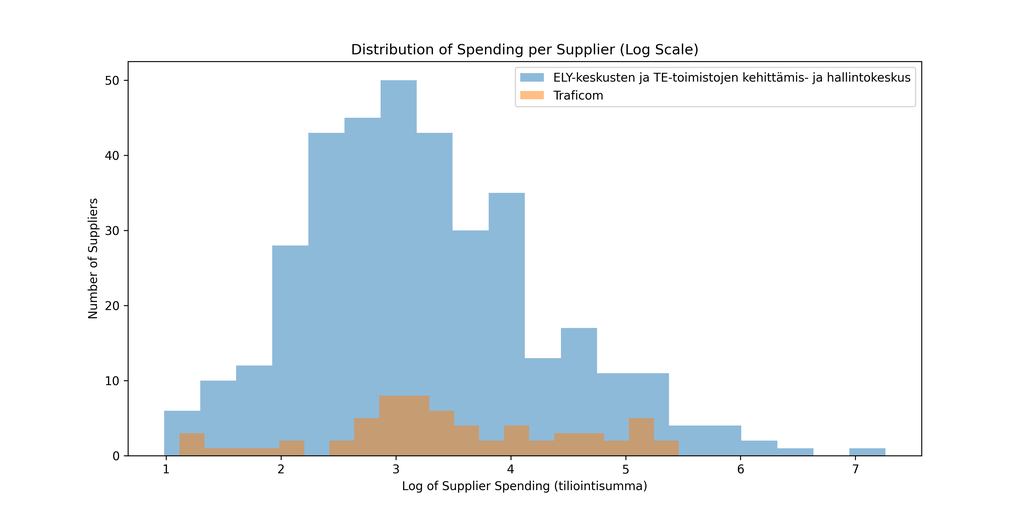

#### Kumulatiivisten kustannusten avulla

ELY-keskusten ja TE-toimistojen kehittämis- ja hallintokeskuksen hallinnonalalla 20–80 % kustannuksista jakautuu vain 6 toimittajalle, mikä tarkoittaa ainoastaan **1,6 % kaikista toimittajista** (365). Traficomin hallinnonalalla vastaava osuus kustannuksista jakautuu 9 toimittajalle, mikä edustaa **14,5 % kaikista toimittajista** (62).

Tämä osoittaa *selkeän eron* hankintojen keskittymisessä. Vaikka ELY-keskusten ja TE-toimistojen kehittämis- ja hallintokeskuksen hallinnonalalla on huomattavasti enemmän toimittajia, hankinnat ovat vahvasti keskittyneet pienelle joukolle. Tämä voi lisätä riippuvuus- ja keskittymisriskejä. Toisaalta, Traficomin hallinnonalalla kustannukset jakautuvat tasaisemmin useamman toimittajan kesken, mikä pienentää keskittymisriskiä ja edistää terveempää kilpailua.

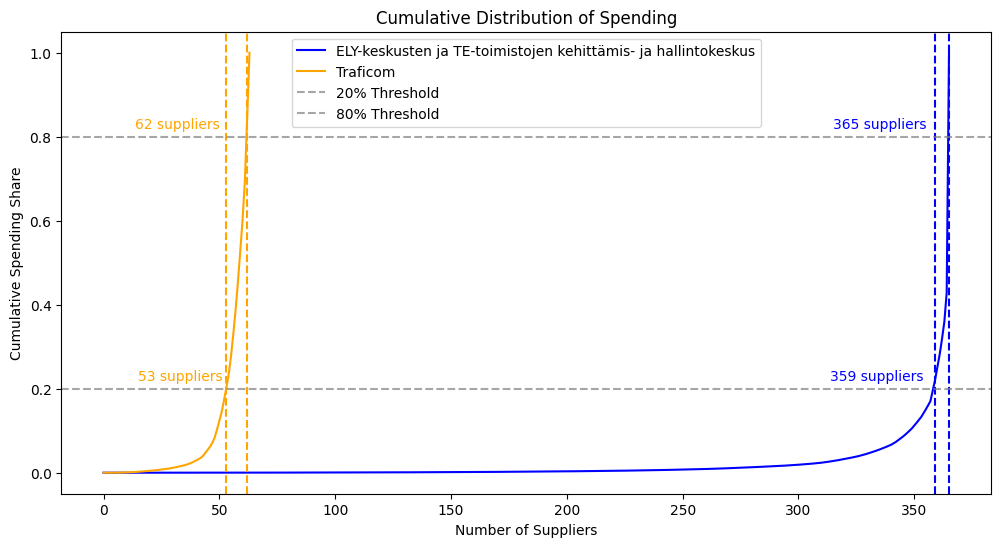

#### Gini kertoimen avulla

Gini-kerroin kuvaa hankintojen jakautumisen tasaisuutta toimittajien kesken. Arvo 0 tarkoittaa täydellistä tasaisuutta ja arvo 1 täydellistä keskittymistä yhdelle toimittajalle. Mitä suurempi arvo, sitä enemmän hankinnat keskittyvät harvoille toimittajille, mikä lisää riippuvuus- ja keskittymisriskejä.

ELY-keskusten ja TE-toimistojen kehittämis- ja hallintokeskuksen Gini-kerroin on **0,962**, mikä on erittäin korkea ja osoittaa **voimakasta keskittymistä**. Traficomin Gini-kerroin on **0,802**, mikä on matalampi, mutta silti **huolestuttavan korkea**. Tämä tarkoittaa, että myös Traficomin hankinnat ovat merkittävästi keskittyneet muutamille toimittajille.

ELY-keskusten hankinnat ovat äärimmäisen keskittyneitä, mutta myös Traficomilla hankintojen jakautuminen kaipaa tasapainottamista. Gini-kerroin osoittaa, että molemmat organisaatiot ovat riskialttiita liialliselle riippuvuudelle harvoista toimittajista.

**Johtopäätökset** ELY-keskusten ja TE-toimistojen kehittämis- ja hallintokeskuksen tilannetta voidaan pitää paradoksaalisena. Vaikka sillä on huomattavasti suurempi määrä toimittajia (366), hankinnat keskittyvät voimakkaasti muutamille toimittajille. Tämä selittää sen, miksi keskittymisriski on korkea. Traficomilla puolestaan on huomattavasti vähemmän toimittajia (64), mutta hankinnat jakautuvat tasaisemmin useamman toimittajan kesken. Tämä tasaisuus pitää Traficomin HHI:n matalana ja vähentää sen keskittymisriskejä.

**Tärkeitä huomioita** Hankintayksiköiden tulisi kiinnittää huomiota paitsi toimittajien määrään myös hankintojen jakautumiseen. Epätasainen jakauma voi johtaa suuriin keskittymisriskeihin, jotka lisäävät riippuvuutta yksittäisistä toimittajista. Lisäksi Gini-indeksi ja kumulatiivisen jakauman tarkastelu tarjoavat hyödyllisiä työkaluja arvioitaessa, miten hankinnat jakautuvat eri toimittajien kesken. Näiden mittareiden avulla on mahdollista tunnistaa riskialueet ja tehdä strategisia muutoksia hankintakäytäntöihin.

### Yläorganisaatioiden tasolla

Päätin tarkistaa, jos keskittyneisyyden arviot muuttuvat, kun hankintoja tarkastellaan hankintayksikköjen yläorganisaatioiden tasolla.

#### HHI indeksin avulla

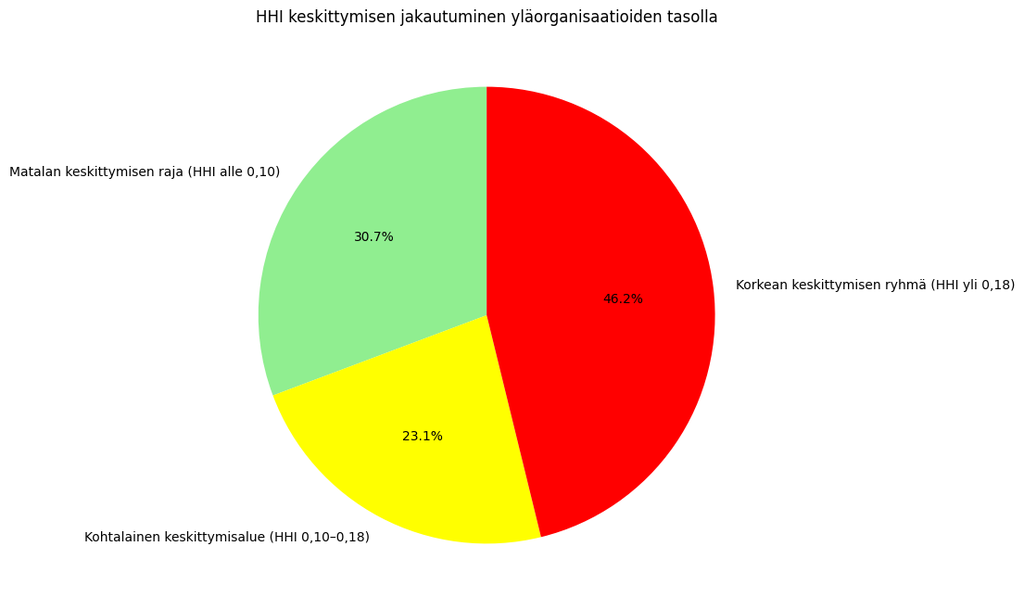

Analyysin tulokset yläosastojen tasolla näyttävät paremmalta. Värikoodaus osoittaa seuraavaa:

|  | yläorganisaatio | HHI |
| --- | --- | --- |
| 0 | Valtioneuvoston kanslia (hallinnonala) | 0.526197 |
| 1 | Oikeusministeriön hallinnonala | 0.353261 |
| 2 | Työ- ja elinkeinoministeriön hallinnonala | 0.320537 |
| 3 | Opetus- ja kulttuuriministeriön hallinnonala | 0.240858 |
| 4 | Tasavallan presidentin kanslia (hallinnonala) | 0.186412 |
| 5 | Ympäristöministeriön hallinnonala | 0.180483 |
| 6 | Sisäministeriön hallinnonala | 0.177551 |
| 7 | Maa- ja metsätalousministeriön hallinnonala | 0.129210 |
| 8 | Sosiaali- ja terveysministeriön hallinnonala | 0.109818 |
| 9 | Ulkoministeriön hallinnonala | 0.089896 |
| 10 | Liikenne- ja viestintäministeriön hallinnonala | 0.086534 |
| 11 | Eduskunta (hallinnonala) | 0.084668 |
| 12 | Valtiovarainministeriön hallinnonala | 0.077031 |

#### Toimittajien määrien ja osuuksien avulla

|  | yläorganisaatio | toimittajien määrä | toimittajien määrän osuus % |
| --- | --- | --- | --- |
| 8 | Työ- ja elinkeinoministeriön hallinnonala | 445 | 17.9 |
| 3 | Oikeusministeriön hallinnonala | 337 | 13.6 |
| 1 | Liikenne- ja viestintäministeriön hallinnonala | 301 | 12.1 |
| 2 | Maa- ja metsätalousministeriön hallinnonala | 275 | 11.1 |
| 11 | Valtiovarainministeriön hallinnonala | 256 | 10.3 |
| 4 | Opetus- ja kulttuuriministeriön hallinnonala | 230 | 9.3 |
| 6 | Sosiaali- ja terveysministeriön hallinnonala | 208 | 8.4 |
| 5 | Sisäministeriön hallinnonala | 141 | 5.7 |
| 12 | Ympäristöministeriön hallinnonala | 80 | 3.2 |
| 0 | Eduskunta (hallinnonala) | 69 | 2.8 |
| 9 | Ulkoministeriön hallinnonala | 67 | 2.7 |
| 10 | Valtioneuvoston kanslia (hallinnonala) | 46 | 1.9 |
| 7 | Tasavallan presidentin kanslia (hallinnonala) | 25 | 1.0 |

#### Kustannusten jakautumisen avulla

Kuvassa esitetään Työ- ja elinkeinoministeriön hallinnonalan (sininen) ja Ulkoministeriön hallinnonalan (oranssi) toimittajakohtainen kustannusjakauma logaritmisessa mittakaavassa.

**Työ- ja elinkeinoministeriön hallinnonala:**

- Jakautuma on erittäin laaja ja painottuu pienempiin kustannuksiin per toimittaja.
- Suuri määrä toimittajia saa suhteellisen pieniä sopimuksia, mikä näkyy logaritmisessa asteikossa vasemmalla puolella (log-arvot välillä 1–3).
- Kuitenkin jakautuma ei ole tasainen, sillä muutama toimittaja hallitsee huomattavasti suurempia sopimuksia, mikä laajentaa jakauman oikealle (log-arvot yli 6).

**Ulkoministeriön hallinnonala:**

- Jakautuma on huomattavasti kapeampi ja keskittyneempi.
- Suurin osa toimittajista saa keskisuuria sopimuksia, eikä jakaumassa ole suuria poikkeamia tai äärimmäisyyksiä verrattuna Työ- ja elinkeinoministeriön hallinnonalaan.
- Tämä tasaisempi jakauma osoittaa hankintojen jakautuvan paremmin eri toimittajien kesken.

Työ- ja elinkeinoministeriön hallinnonalan hankinnat **eivät jakaudu tasaisesti** toimittajien kesken. Vaikka toimittajia on paljon, suuri osa hankinnoista keskittyy muutamille toimittajille, mikä lisää keskittymisriskiä. Tämä epätasainen jakauma voi aiheuttaa riippuvuutta suurista toimittajista ja vähentää kilpailun mahdollisuuksia.

Ulkoministeriön hallinnonalan kustannusjakauma on sen sijaan **huomattavasti tasaisempi**, mikä tarkoittaa, että hankinnat jakautuvat tasapuolisemmin eri toimittajien kesken. Tämä pienentää merkittävästi riippuvuutta yksittäisistä toimittajista ja mahdollistaa terveemmän kilpailun.

Ulkoministeriön tasainen jakauma edistää kilpailua ja vähentää hankintojen keskittymisen riskejä. Toisaalta Työ- ja elinkeinoministeriön hallinnonalan jakauman epätasaisuus osoittaa, että suuret sopimukset keskittyvät vain muutamille toimittajille, mikä voi johtaa riippuvuuteen näistä toimittajista ja altistaa organisaation riskeille. Logaritmisen asteikon käyttö auttaa tunnistamaan nämä erot ja arvioimaan hankintojen tasaisuutta tarkemmin.

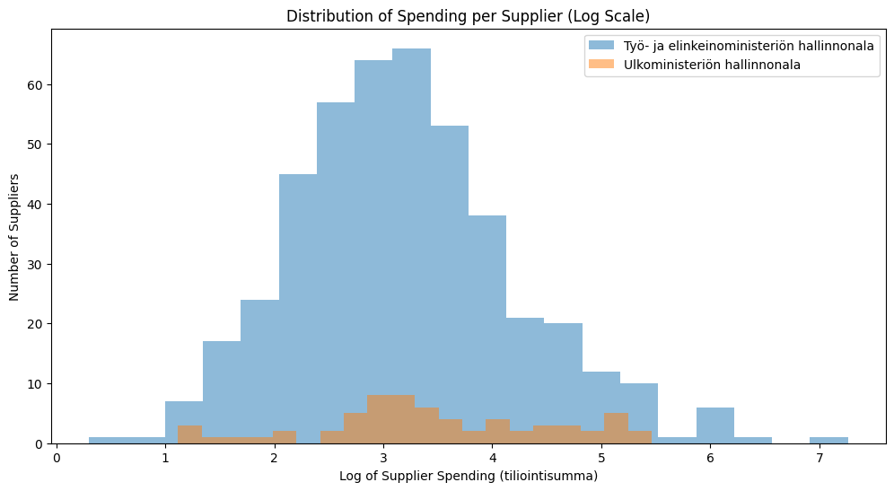

#### Kumulatiivisten kustannusten avulla

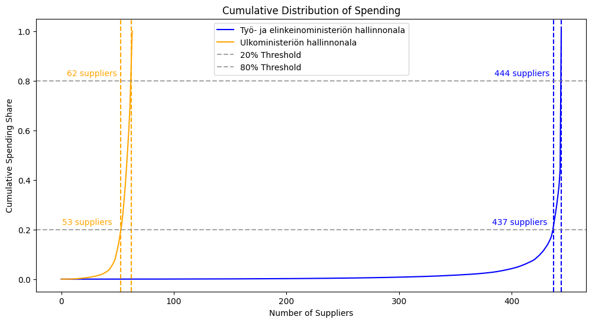

#### Gini kertoimen avulla

Työ- ja elinkeinoministeriön hallinnonalan Gini-kerroin on **0,963**, mikä on **erittäin korkea** ja osoittaa voimakasta keskittymistä. Ulkoministeriön hallinnonalan Gini-kerroin on **0,802**, mikä on matalampi, mutta silti **huolestuttavan korkea**. Tämä tarkoittaa, että myös Ulkoministeriön hallinnonalan hankinnat ovat merkittävästi keskittyneet muutamille toimittajille.

Työ- ja elinkeinoministeriön hallinnonalan hankinnat ovat äärimmäisen keskittyneitä, mutta myös Ulkoministeriön hallinnonalalla hankintojen jakautuminen kaipaa tasapainottamista. Gini-kerroin osoittaa, että molemmat organisaatiot ovat riskialttiita liialliselle riippuvuudelle harvoista toimittajista.

## Maantieteelliset erot

### Toimittajien kotipaikat

#### Yritysten määrän perusteella

Yli kolmasosa toimittajista rekisteröity **Helsingissä**

[output not shown]

#### Yritysten saatujen hankinta-tiliointien perusteella

|  | Kotipaikka | tiliointisumma | prosentti |
| --- | --- | --- | --- |
| 0 | Helsinki | 40927883.23 | 53.37 |
| 1 | Tuusula | 18278801.47 | 23.84 |
| 2 | Vantaa | 4489622.90 | 5.85 |
| 3 | Espoo | 3888248.23 | 5.07 |
| 4 | Jyväskylä | 2313972.01 | 3.02 |
| ... | ... | ... | ... |
| 139 | Nykarleby | 54.91 | 0.00 |
| 140 | Kemijärvi | 52.79 | 0.00 |
| 141 | Eurajoki | 49.12 | 0.00 |
| 142 | Lappträsk | 19.92 | 0.00 |
| 143 | Viitasaari | 3.21 | 0.00 |

144 rows × 3 columns

### Palvelut riippuen kotipaikasta

#### Helsingissä sijaitsevien yritysten tuomat palvelut

**90 % kustannuksista** menee kattavat **40 % hankkeita** ja osuvat kuuteen tuote/palveluryhmiin:

- Rakennusten ja huoneistojen vuokrat
- Muut palvelut
- Rakenteet
- Rakentamis-, korjaus- ja kunnossapitopalvelut
- ICT-palvelut
- Väylähankkeet

[figure not shown]

|  | tuote_palveluryhma | määrä | summa | % kustannuksista | % hankintojen määrästä |
| --- | --- | --- | --- | --- | --- |
| 29 | Rakennusten ja huoneistojen vuokrat | 918 | 16320511.30 | 39.9 | 19.1 |
| 20 | Muut palvelut | 445 | 6342751.49 | 15.5 | 9.2 |
| 31 | Rakenteet | 101 | 5825074.50 | 14.2 | 2.1 |
| 30 | Rakentamis-, korjaus- ja kunnossapitopalvelut | 195 | 4319075.21 | 10.6 | 4.0 |
| 6 | ICT-palvelut | 252 | 2433220.12 | 5.9 | 5.2 |
| 40 | Väylähankkeet | 3 | 1645451.24 | 4.0 | 0.1 |
| 35 | Työterveyspalvelut | 72 | 750242.29 | 1.8 | 1.5 |
| 27 | Puhtaanapito- ja pesulapalvelut | 421 | 694408.33 | 1.7 | 8.7 |
| 1 | Asiantuntija- ja tutkimuspalvelut | 97 | 669356.68 | 1.6 | 2.0 |
| 38 | Vartiointi- ja turvallisuuspalvelut | 337 | 327747.57 | 0.8 | 7.0 |
| 9 | Koneiden, laitteiden ja kuljetusvälineiden vuo... | 71 | 267426.02 | 0.7 | 1.5 |
| 21 | Muut vuokrat | 155 | 240437.94 | 0.6 | 3.2 |
| 25 | Posti- ja kuriiripalvelut | 104 | 238788.71 | 0.6 | 2.2 |
| 33 | Sähkö ja kaasu | 331 | 191276.68 | 0.5 | 6.9 |
| 22 | Ohjelmistot ja aineettomat oikeudet | 23 | 89944.36 | 0.2 | 0.5 |
| 12 | Lämmitys | 23 | 81203.06 | 0.2 | 0.5 |
| 23 | Painatukset, ilmoitukset ja markkinointi | 100 | 71671.78 | 0.2 | 2.1 |
| 11 | Käännös- ja tulkkauspalvelut | 96 | 62955.92 | 0.2 | 2.0 |
| 32 | Ravitsemispalvelut | 97 | 53926.43 | 0.1 | 2.0 |
| 3 | Henkilöstön koulutuspalvelut | 61 | 51927.10 | 0.1 | 1.3 |
| 17 | Muut henkilöstöpalvelut | 30 | 51762.97 | 0.1 | 0.6 |
| 15 | Muut aineet, tarvikkeet ja tavarat | 181 | 45429.59 | 0.1 | 3.8 |
| 16 | Muut asiantuntija- ja toimistopalvelut | 35 | 37575.14 | 0.1 | 0.7 |
| 34 | Toimisto- ja koulutarvikkeet | 327 | 19525.92 | 0.0 | 6.8 |
| 8 | Koneiden, laitteiden ja kaluston kunnossapitop... | 22 | 16081.61 | 0.0 | 0.5 |
| 13 | Maanvuokrat | 13 | 14073.02 | 0.0 | 0.3 |
| 14 | Matkustuspalvelut | 60 | 13564.01 | 0.0 | 1.2 |
| 0 | Arvoltaan vähäiset koneet, kalusteet ja kuljet... | 12 | 11251.23 | 0.0 | 0.2 |
| 4 | Henkilöstön virkistyspalvelut | 31 | 9274.48 | 0.0 | 0.6 |
| 2 | Elintarvikkeet, juomat ja tupakka | 93 | 8707.89 | 0.0 | 1.9 |
| 5 | ICT-laitteet | 4 | 3911.11 | 0.0 | 0.1 |
| 26 | Puhdistusaineet ja -tarvikkeet | 17 | 3760.43 | 0.0 | 0.4 |
| 39 | Vesi | 9 | 3632.47 | 0.0 | 0.2 |
| 18 | Muut kulut | 18 | 3618.39 | 0.0 | 0.4 |
| 7 | Kirjat, lehdet ja muut painotuotteet | 19 | 3266.28 | 0.0 | 0.4 |
| 37 | Varaosat | 5 | 1532.27 | 0.0 | 0.1 |
| 36 | Vaatteisto | 20 | 1352.50 | 0.0 | 0.4 |
| 10 | Kunnossapitopalvelut | 8 | 1145.40 | 0.0 | 0.2 |
| 24 | Poltto- ja voiteluaineet | 1 | 486.06 | 0.0 | 0.0 |
| 19 | Muut kustannusten korvaukset | 6 | 436.17 | 0.0 | 0.1 |
| 28 | Rakennusmateriaali | 2 | 99.56 | 0.0 | 0.0 |

#### Minkä yksiköt vuokraavat eniten Helsingissä?

|  | hankintayksikko | määrä | summa | % kustannuksista |
| --- | --- | --- | --- | --- |
| 20 | Rikosseuraamuslaitos | 50 | 2594508.78 | 15.9 |
| 34 | Valtioneuvoston kanslia | 16 | 1820566.48 | 11.2 |
| 29 | Tulli | 134 | 1475663.88 | 9.0 |
| 1 | ELY-keskusten ja TE-toimistojen kehittämis- ja... | 67 | 1302825.27 | 8.0 |
| 30 | Tuomioistuinlaitos | 43 | 1281172.99 | 7.9 |
| 17 | Opetushallitus | 20 | 1152491.22 | 7.1 |
| 21 | Ruokavirasto | 8 | 837197.66 | 5.1 |
| 27 | Terveyden ja hyvinvoinnin laitos | 97 | 777807.70 | 4.8 |
| 36 | Verohallinto | 26 | 640569.38 | 3.9 |
| 28 | Tilastokeskus | 4 | 475214.04 | 2.9 |
| 8 | Liikenne- ja viestintävirasto Traficom | 26 | 384519.66 | 2.4 |
| 24 | Suomen ympäristökeskus | 10 | 393574.58 | 2.4 |

#### Millä yksiköillä kalleimmat vuokrahankinnat?

|  | hankintayksikko | määrä | summa | hankinnan keskihinta |
| --- | --- | --- | --- | --- |
| 28 | Tilastokeskus | 4 | 475214.04 | 11880351.0 |
| 34 | Valtioneuvoston kanslia | 16 | 1820566.48 | 11378540.5 |
| 21 | Ruokavirasto | 8 | 837197.66 | 10464970.7 |
| 17 | Opetushallitus | 20 | 1152491.22 | 5762456.1 |
| 20 | Rikosseuraamuslaitos | 50 | 2594508.78 | 5189017.6 |
| 24 | Suomen ympäristökeskus | 10 | 393574.58 | 3935745.8 |
| 6 | Kansallisarkisto | 4 | 146825.10 | 3670627.5 |
| 10 | Lääkealan turvallisuus- ja kehittämiskeskus | 2 | 70706.00 | 3535300.0 |
| 15 | Oikeusrekisterikeskus | 2 | 63842.18 | 3192109.0 |
| 30 | Tuomioistuinlaitos | 43 | 1281172.99 | 2979472.1 |
| 36 | Verohallinto | 26 | 640569.38 | 2463728.4 |
| 18 | Pelastusopisto | 10 | 230364.28 | 2303642.8 |

#### Muualla kuin Helsingissä sijaistevien yritysten palvelut

**90 % kustannuksista** kattavat **30 % hankkeista** ja osuvat neljään tuote/palveluryhmään:

- Rakenteet
- ICT-palvelut
- Rakentamis-, korjaus- ja kunnossapitopalvelut
- Asiantuntija- ja tutkimuspalvelut

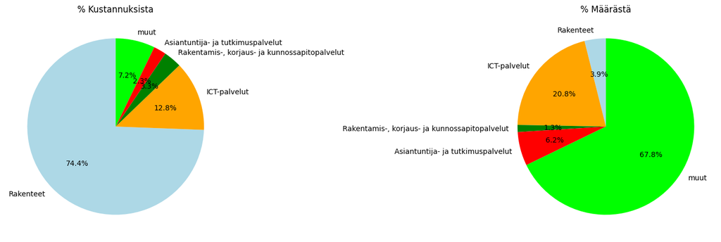

|  | tuote_palveluryhma | määrä | summa | % kustannuksista | % määrästä |
| --- | --- | --- | --- | --- | --- |
| 30 | Rakenteet | 118 | 26617957.83 | 74.4 | 3.9 |
| 6 | ICT-palvelut | 625 | 4583796.03 | 12.8 | 20.8 |
| 29 | Rakentamis-, korjaus- ja kunnossapitopalvelut | 38 | 1194950.27 | 3.3 | 1.3 |
| 1 | Asiantuntija- ja tutkimuspalvelut | 186 | 835390.63 | 2.3 | 6.2 |
| 18 | Muut palvelut | 256 | 559148.29 | 1.6 | 8.5 |
| 32 | Sähkö ja kaasu | 607 | 493689.21 | 1.4 | 20.2 |
| 28 | Rakennusten ja huoneistojen vuokrat | 55 | 399856.98 | 1.1 | 1.8 |
| 20 | Ohjelmistot ja aineettomat oikeudet | 12 | 132852.98 | 0.4 | 0.4 |
| 8 | Koneiden, laitteiden ja kaluston kunnossapitop... | 80 | 113917.01 | 0.3 | 2.7 |
| 14 | Muut aineet, tarvikkeet ja tavarat | 206 | 106623.97 | 0.3 | 6.8 |
| 38 | Varaosat | 5 | 104745.21 | 0.3 | 0.2 |
| 25 | Puhtaanapito- ja pesulapalvelut | 24 | 88419.28 | 0.2 | 0.8 |
| 4 | Henkilöstön koulutuspalvelut | 43 | 78463.89 | 0.2 | 1.4 |
| 31 | Ravitsemispalvelut | 89 | 60717.15 | 0.2 | 3.0 |
| 11 | Käännös- ja tulkkauspalvelut | 84 | 58475.69 | 0.2 | 2.8 |
| 10 | Kunnossapitopalvelut | 12 | 55807.87 | 0.2 | 0.4 |
| 0 | Arvoltaan vähäiset koneet, kalusteet ja kuljet... | 16 | 54339.71 | 0.2 | 0.5 |
| 21 | Painatukset, ilmoitukset ja markkinointi | 57 | 33622.34 | 0.1 | 1.9 |
| 5 | Henkilöstön virkistyspalvelut | 24 | 27548.82 | 0.1 | 0.8 |
| 13 | Matkustuspalvelut | 68 | 21709.86 | 0.1 | 2.3 |
| 33 | Talous- ja henkilöstöhallinnon palvelujen osto... | 4 | 21303.90 | 0.1 | 0.1 |
| 9 | Koneiden, laitteiden ja kuljetusvälineiden vuo... | 70 | 21187.43 | 0.1 | 2.3 |
| 19 | Muut vuokrat | 33 | 17476.66 | 0.0 | 1.1 |
| 2 | Elintarvikkeet, juomat ja tupakka | 82 | 12437.73 | 0.0 | 2.7 |
| 12 | Lämmitys | 7 | 9870.49 | 0.0 | 0.2 |
| 36 | Vaatteisto | 11 | 9064.00 | 0.0 | 0.4 |
| 24 | Puhdistusaineet ja -tarvikkeet | 49 | 7407.49 | 0.0 | 1.6 |
| 27 | Rakennusmateriaali | 13 | 6661.49 | 0.0 | 0.4 |
| 34 | Toimisto- ja koulutarvikkeet | 35 | 6058.86 | 0.0 | 1.2 |
| 16 | Muut kulut | 31 | 5501.50 | 0.0 | 1.0 |
| 7 | Kirjat, lehdet ja muut painotuotteet | 13 | 4848.43 | 0.0 | 0.4 |
| 40 | Vesi | 10 | 3158.06 | 0.0 | 0.3 |
| 22 | Poltto- ja voiteluaineet | 4 | 2603.34 | 0.0 | 0.1 |
| 35 | Työterveyspalvelut | 6 | 2023.02 | 0.0 | 0.2 |
| 39 | Vartiointi- ja turvallisuuspalvelut | 9 | 1954.49 | 0.0 | 0.3 |
| 23 | Posti- ja kuriiripalvelut | 11 | 1688.22 | 0.0 | 0.4 |
| 17 | Muut kustannusten korvaukset | 9 | 1680.04 | 0.0 | 0.3 |
| 41 | Väylähankkeet | 1 | 1267.37 | 0.0 | 0.0 |
| 15 | Muut henkilöstöpalvelut | 3 | 1025.00 | 0.0 | 0.1 |
| 3 | Ennakkomaksut ja keskeneräiset hankinnat | 1 | 779.00 | 0.0 | 0.0 |
| 26 | Rahoitus- ja pankkipalvelut | 3 | 606.97 | 0.0 | 0.1 |
| 37 | Vakuutukset ja vahinkomaksut | 1 | 86.04 | 0.0 | 0.0 |

#### Helsingistä ja muualta kuin Helsingistä plavelujen vertailu

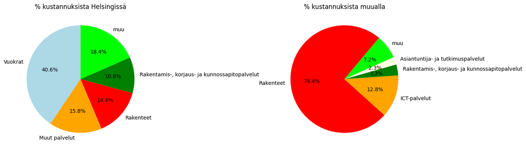

## Montako hankintakategorioita eri yksiköt hankkivat?

### Hankintayksikköiden hankintakategoriat

|  | hankintayksikko | hankintakategoria |
| --- | --- | --- |
| 2 | ELY-keskusten ja TE-toimistojen kehittämis- ja... | 12 |
| 14 | Luonnonvarakeskus | 11 |
| 45 | Ulkoministeriö | 11 |
| 56 | Väylävirasto | 11 |
| 7 | Hätäkeskuslaitos | 10 |
| 6 | Geologian tutkimuskeskus | 10 |
| 25 | Pelastusopisto | 10 |
| 20 | Oikeusministeriö | 10 |
| 5 | Etelä-Suomen aluehallintovirasto | 10 |
| 22 | Opetus- ja kulttuuriministeriö | 10 |
| 18 | Maanmittauslaitos | 10 |
| 23 | Opetushallitus | 10 |
| 51 | Valtion tieto- ja viestintätekniikkakeskus Val... | 10 |
| 42 | Tuomioistuinlaitos | 10 |
| 28 | Ruokavirasto | 10 |
| 27 | Rikosseuraamuslaitos | 10 |
| 17 | Maahanmuuttovirasto | 10 |
| 55 | Verohallinto | 10 |
| 34 | Suomen ympäristökeskus | 10 |
| 39 | Terveyden ja hyvinvoinnin laitos | 10 |
| 3 | Eduskunta | 10 |
| 8 | Ilmatieteen laitos | 9 |
| 37 | Säteilyturvakeskus | 9 |
| 52 | Valtioneuvoston kanslia | 9 |
| 36 | Syyttäjälaitos | 9 |
| 13 | Liikenne- ja viestintävirasto Traficom | 9 |
| 31 | Sosiaali- ja terveysministeriö | 9 |
| 40 | Tilastokeskus | 9 |
| 43 | Turvallisuus- ja kemikaalivirasto | 8 |
| 53 | Valtiontalouden tarkastusvirasto | 8 |
| 50 | Valtion talous- ja henkilöstöhallinnon palvelu... | 8 |
| 41 | Tulli | 8 |
| 29 | Sisäministeriö | 8 |
| 35 | Suomenlinnan hoitokunta | 8 |
| 1 | Digi- ja väestötietovirasto | 8 |
| 15 | Lääkealan turvallisuus- ja kehittämiskeskus | 8 |
| 24 | Patentti- ja rekisterihallitus | 8 |
| 10 | Kansallisarkisto | 8 |
| 26 | Rahoitusvakausvirasto | 7 |
| 12 | Liikenne- ja viestintäministeriö | 7 |
| 19 | Museovirasto | 7 |
| 21 | Oikeusrekisterikeskus | 7 |
| 48 | Valtiokonttori | 7 |
| 47 | Ulosottolaitos | 7 |
| 33 | Suomen Akatemia | 7 |
| 30 | Sosiaali- ja terveysalan lupa- ja valvontavirasto | 7 |
| 0 | Asumisen rahoitus- ja kehittämiskeskus | 6 |
| 38 | Tasavallan presidentin kanslia | 6 |
| 9 | Innovaatiorahoituskeskus Business Finland | 6 |
| 16 | Maa- ja metsätalousministeriö | 6 |
| 11 | Kilpailu- ja kuluttajavirasto | 5 |
| 4 | Energiavirasto | 5 |
| 54 | Valtiovarainministeriö | 5 |
| 44 | Työ- ja elinkeinoministeriö | 5 |
| 57 | Ympäristöministeriö | 5 |
| 32 | Sosiaaliturva-asioiden muutoksenhakulautakunta | 4 |
| 49 | Valtion taloudellinen tutkimuskeskus | 4 |
| 46 | Ulkopoliittinen instituutti | 2 |

### Hankintayksikköiden hankkimat palveluryhmät

|  | hankintayksikko | tuote_palveluryhmien määrä |
| --- | --- | --- |
| 2 | ELY-keskusten ja TE-toimistojen kehittämis- ja... | 37 |
| 39 | Terveyden ja hyvinvoinnin laitos | 33 |
| 14 | Luonnonvarakeskus | 32 |
| 27 | Rikosseuraamuslaitos | 31 |
| 17 | Maahanmuuttovirasto | 30 |
| 56 | Väylävirasto | 30 |
| 42 | Tuomioistuinlaitos | 28 |
| 8 | Ilmatieteen laitos | 28 |
| 20 | Oikeusministeriö | 27 |
| 23 | Opetushallitus | 27 |
| 3 | Eduskunta | 25 |
| 52 | Valtioneuvoston kanslia | 25 |
| 51 | Valtion tieto- ja viestintätekniikkakeskus Val... | 25 |
| 34 | Suomen ympäristökeskus | 23 |
| 41 | Tulli | 23 |
| 5 | Etelä-Suomen aluehallintovirasto | 23 |
| 6 | Geologian tutkimuskeskus | 23 |
| 22 | Opetus- ja kulttuuriministeriö | 23 |
| 18 | Maanmittauslaitos | 22 |
| 36 | Syyttäjälaitos | 22 |
| 45 | Ulkoministeriö | 21 |
| 13 | Liikenne- ja viestintävirasto Traficom | 21 |
| 47 | Ulosottolaitos | 20 |
| 55 | Verohallinto | 20 |
| 7 | Hätäkeskuslaitos | 20 |
| 37 | Säteilyturvakeskus | 20 |
| 28 | Ruokavirasto | 19 |
| 19 | Museovirasto | 18 |
| 25 | Pelastusopisto | 17 |
| 1 | Digi- ja väestötietovirasto | 16 |
| 35 | Suomenlinnan hoitokunta | 16 |
| 50 | Valtion talous- ja henkilöstöhallinnon palvelu... | 15 |
| 40 | Tilastokeskus | 14 |
| 38 | Tasavallan presidentin kanslia | 14 |
| 10 | Kansallisarkisto | 14 |
| 15 | Lääkealan turvallisuus- ja kehittämiskeskus | 14 |
| 29 | Sisäministeriö | 13 |
| 30 | Sosiaali- ja terveysalan lupa- ja valvontavirasto | 13 |
| 24 | Patentti- ja rekisterihallitus | 13 |
| 31 | Sosiaali- ja terveysministeriö | 12 |
| 21 | Oikeusrekisterikeskus | 11 |
| 53 | Valtiontalouden tarkastusvirasto | 11 |
| 48 | Valtiokonttori | 10 |
| 43 | Turvallisuus- ja kemikaalivirasto | 10 |
| 33 | Suomen Akatemia | 10 |
| 26 | Rahoitusvakausvirasto | 9 |
| 9 | Innovaatiorahoituskeskus Business Finland | 9 |
| 4 | Energiavirasto | 9 |
| 11 | Kilpailu- ja kuluttajavirasto | 9 |
| 12 | Liikenne- ja viestintäministeriö | 9 |
| 44 | Työ- ja elinkeinoministeriö | 9 |
| 0 | Asumisen rahoitus- ja kehittämiskeskus | 8 |
| 16 | Maa- ja metsätalousministeriö | 8 |
| 57 | Ympäristöministeriö | 7 |
| 32 | Sosiaaliturva-asioiden muutoksenhakulautakunta | 5 |
| 49 | Valtion taloudellinen tutkimuskeskus | 5 |
| 54 | Valtiovarainministeriö | 5 |
| 46 | Ulkopoliittinen instituutti | 3 |

### Tuote/palveluryhmien määrät ja kustannukset

#### Eniten hankitut tuote/palveluryhmät

|  | tuote_palveluryhma | määrä |
| --- | --- | --- |
| 8 | ICT-palvelut | 1424 |
| 24 | Muut palvelut | 972 |
| 38 | Sähkö ja kaasu | 932 |
| 19 | Muut aineet, tarvikkeet ja tavarat | 737 |
| 34 | Rakennusten ja huoneistojen vuokrat | 617 |
| 15 | Käännös- ja tulkkauspalvelut | 565 |
| 1 | Asiantuntija- ja tutkimuspalvelut | 552 |
| 40 | Toimisto- ja koulutarvikkeet | 421 |
| 36 | Rakenteet | 419 |
| 37 | Ravitsemispalvelut | 370 |
| 18 | Matkustuspalvelut | 336 |
| 31 | Puhtaanapito- ja pesulapalvelut | 319 |
| 27 | Painatukset, ilmoitukset ja markkinointi | 317 |
| 35 | Rakentamis-, korjaus- ja kunnossapitopalvelut | 279 |
| 42 | Vaatteisto | 247 |
| 2 | Elintarvikkeet, juomat ja tupakka | 242 |
| 4 | Henkilöstön koulutuspalvelut | 228 |
| 45 | Vartiointi- ja turvallisuuspalvelut | 212 |
| 29 | Posti- ja kuriiripalvelut | 195 |
| 12 | Koneiden, laitteiden ja kaluston kunnossapitop... | 179 |
| 13 | Koneiden, laitteiden ja kuljetusvälineiden vuo... | 164 |
| 25 | Muut vuokrat | 147 |
| 21 | Muut henkilöstöpalvelut | 86 |
| 22 | Muut kulut | 85 |
| 6 | Henkilöstön virkistyspalvelut | 83 |
| 41 | Työterveyspalvelut | 79 |
| 30 | Puhdistusaineet ja -tarvikkeet | 74 |
| 10 | Kirjat, lehdet ja muut painotuotteet | 72 |
| 26 | Ohjelmistot ja aineettomat oikeudet | 69 |
| 20 | Muut asiantuntija- ja toimistopalvelut | 68 |
| 28 | Poltto- ja voiteluaineet | 67 |
| 0 | Arvoltaan vähäiset koneet, kalusteet ja kuljet... | 49 |
| 16 | Lämmitys | 43 |
| 14 | Kunnossapitopalvelut | 36 |
| 46 | Vesi | 25 |
| 33 | Rakennusmateriaali | 16 |
| 23 | Muut kustannusten korvaukset | 16 |
| 47 | Väylähankkeet | 15 |
| 7 | ICT-laitteet | 12 |
| 44 | Varaosat | 10 |
| 17 | Maanvuokrat | 9 |
| 32 | Rahoitus- ja pankkipalvelut | 5 |
| 11 | Koneet, laitteet ja kalusto | 5 |
| 39 | Talous- ja henkilöstöhallinnon palvelujen osto... | 4 |
| 3 | Ennakkomaksut ja keskeneräiset hankinnat | 2 |
| 5 | Henkilöstön matkustus- ja kuljetuspalvelut | 1 |
| 9 | Jäsenmaksut | 1 |
| 43 | Vakuutukset ja vahinkomaksut | 1 |

#### Kustannukset tuote/palveluryhmittäin

|  | tuote_palveluryhma | kustannukset |
| --- | --- | --- |
| 36 | Rakenteet | 37697349.06 |
| 8 | ICT-palvelut | 10429033.92 |
| 34 | Rakennusten ja huoneistojen vuokrat | 8966442.37 |
| 35 | Rakentamis-, korjaus- ja kunnossapitopalvelut | 6401349.59 |
| 24 | Muut palvelut | 5379781.73 |
| 1 | Asiantuntija- ja tutkimuspalvelut | 3002387.28 |
| 47 | Väylähankkeet | 2219363.27 |
| 41 | Työterveyspalvelut | 752395.31 |
| 38 | Sähkö ja kaasu | 664371.79 |
| 26 | Ohjelmistot ja aineettomat oikeudet | 515232.25 |
| 31 | Puhtaanapito- ja pesulapalvelut | 514312.83 |
| 19 | Muut aineet, tarvikkeet ja tavarat | 422110.20 |
| 12 | Koneiden, laitteiden ja kaluston kunnossapitop... | 317513.34 |
| 29 | Posti- ja kuriiripalvelut | 306331.18 |
| 4 | Henkilöstön koulutuspalvelut | 295290.45 |
| 13 | Koneiden, laitteiden ja kuljetusvälineiden vuo... | 286808.64 |
| 45 | Vartiointi- ja turvallisuuspalvelut | 243262.21 |
| 15 | Käännös- ja tulkkauspalvelut | 234874.15 |
| 37 | Ravitsemispalvelut | 221074.94 |
| 11 | Koneet, laitteet ja kalusto | 205966.00 |
| 21 | Muut henkilöstöpalvelut | 170597.90 |
| 25 | Muut vuokrat | 166621.99 |
| 27 | Painatukset, ilmoitukset ja markkinointi | 161984.80 |
| 14 | Kunnossapitopalvelut | 132956.32 |
| 18 | Matkustuspalvelut | 126701.36 |
| 16 | Lämmitys | 125658.62 |
| 0 | Arvoltaan vähäiset koneet, kalusteet ja kuljet... | 121897.40 |
| 44 | Varaosat | 106277.48 |
| 6 | Henkilöstön virkistyspalvelut | 85826.66 |
| 7 | ICT-laitteet | 84575.03 |
| 2 | Elintarvikkeet, juomat ja tupakka | 71485.86 |
| 20 | Muut asiantuntija- ja toimistopalvelut | 51285.48 |
| 40 | Toimisto- ja koulutarvikkeet | 46484.16 |
| 22 | Muut kulut | 35054.64 |
| 42 | Vaatteisto | 30384.59 |
| 39 | Talous- ja henkilöstöhallinnon palvelujen osto... | 21303.90 |
| 10 | Kirjat, lehdet ja muut painotuotteet | 15543.05 |
| 30 | Puhdistusaineet ja -tarvikkeet | 13901.29 |
| 46 | Vesi | 13151.11 |
| 28 | Poltto- ja voiteluaineet | 12482.08 |
| 17 | Maanvuokrat | 8641.30 |
| 33 | Rakennusmateriaali | 7142.58 |
| 3 | Ennakkomaksut ja keskeneräiset hankinnat | 3279.00 |
| 23 | Muut kustannusten korvaukset | 2272.26 |
| 9 | Jäsenmaksut | 1500.00 |
| 32 | Rahoitus- ja pankkipalvelut | 651.22 |
| 5 | Henkilöstön matkustus- ja kuljetuspalvelut | 234.00 |
| 43 | Vakuutukset ja vahinkomaksut | 86.04 |

### Hankintakategorioiden määrät ja kustannukset

#### Eniten hankitut hankintakategoriat

|  | hankintakategoria | määrä |
| --- | --- | --- |
| 10 | Rakennusten ja alueiden ylläpito | 2193 |
| 0 | Aineet, tarvikkeet ja tavarat | 1870 |
| 3 | Hallinnolliset palvelut | 1727 |
| 5 | ICT-hankinnat (tavarat, palvelut ja ohjelmistot) | 1505 |
| 2 | Asiantuntija- ja toimistopalvelut | 1185 |
| 1 | Alueet ja väylät | 434 |
| 6 | Koneet, laitteet ja kuljetusvälineet | 399 |
| 8 | Majoitus- ja ravitsemispalvelut | 370 |
| 9 | Matkustus- ja kuljetuspalvelut | 337 |
| 7 | Koulutus- ja kulttuuripalvelut | 311 |
| 11 | Rakentaminen | 295 |
| 4 | Henkilöstöpalvelut | 181 |

#### Kustannukset hankintakategorioittain

|  | hankintakategoria | kustannukset |
| --- | --- | --- |
| 1 | Alueet ja väylät | 39916712.33 |
| 5 | ICT-hankinnat (tavarat, palvelut ja ohjelmistot) | 11028841.20 |
| 10 | Rakennusten ja alueiden ylläpito | 10668796.55 |
| 11 | Rakentaminen | 6408492.17 |
| 3 | Hallinnolliset palvelut | 6073315.50 |
| 2 | Asiantuntija- ja toimistopalvelut | 3288546.91 |
| 6 | Koneet, laitteet ja kuljetusvälineet | 935464.38 |
| 4 | Henkilöstöpalvelut | 925265.47 |
| 0 | Aineet, tarvikkeet ja tavarat | 718668.71 |
| 7 | Koulutus- ja kulttuuripalvelut | 381117.11 |
| 8 | Majoitus- ja ravitsemispalvelut | 221074.94 |
| 9 | Matkustus- ja kuljetuspalvelut | 126935.36 |

## Toimittajien luotettavuus

### Paljonko maksoivat hankinnat toimittajille, joilla on vähintään yksi merkintä vastuullisuustarkastuksessa

```
Yhteensä valtion hankinnat maksoivat: 76688605.77999999 euroa
Maksettu yrityksille, joilla on vastuullisuusmerkintä: 25133240.090000004 euroa
Prosenttina se on:  32.8
```

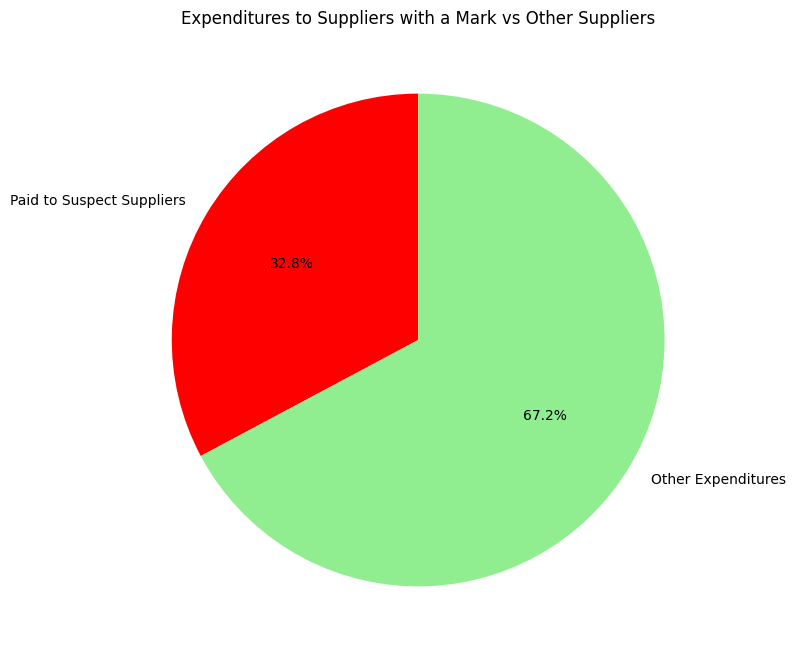

### Ketkä ovat ne toimittajat, joilla on merkintä, ja paljonko ne saivat hankinnoista?

|  | toimittaja_y_tunnus | toimittaja_nimi | tiliointisumma | tiliointisumma_percent |
| --- | --- | --- | --- | --- |
| 1 | 1503388-4 | Senaatti-kiinteistöt | 17751211.10 | 23.15 |
| 15 | 2163026-3 | Destia Oy | 2618857.82 | 3.41 |
| 2 | 1508718-8 | Destia Rail Oy | 2522959.29 | 3.29 |
| 23 | 2574261-7 | Valtion tieto- ja viestintätekniikkakeskus Val... | 1903395.30 | 2.48 |
| 18 | 2344200-4 | Posti Oy | 79723.46 | 0.10 |
| 5 | 1567535-0 | HUS-yhtymä | 75019.60 | 0.10 |
| 0 | 1003521-5 | VR-Yhtymä Oyj | 36203.81 | 0.05 |
| 13 | 1874314-4 | Pääkaupunkiseudun Junakalusto Oy | 27052.43 | 0.04 |
| 17 | 2288666-6 | Poliisihallitus | 27555.57 | 0.04 |
| 27 | 3221313-1 | ETELÄ-KARJALAN HYVINVOINTIALUE | 25076.70 | 0.03 |
| 8 | 1735961-8 | PunaMusta Oy | 15498.71 | 0.02 |
| 31 | 9129466-4 | Utsjoki | 16465.41 | 0.02 |
| 4 | 1548234-8 | Eltel Networks Oy | 7259.50 | 0.01 |
| 3 | 1515901-4 | Sanoma Media Finland Oy | 4887.96 | 0.01 |
| 24 | 2717767-4 | DHL Express (Finland) Oy | 6755.64 | 0.01 |
| 6 | 1589543-3 | Auto-Suni Oy | 13.79 | 0.00 |
| 14 | 2060706-1 | Teroprint Oy | 100.00 | 0.00 |
| 12 | 1868785-9 | Tervolan Energia ja Vesi Oy | 47.52 | 0.00 |
| 10 | 1837957-3 | HOK-Elanto Liiketoiminta Oy | 1606.46 | 0.00 |
| 11 | 1868393-8 | Lounais-Suomen Jätehuolto Oy | 62.81 | 0.00 |
| 9 | 1827711-2 | Silmäasema Optiikka Oy | 1333.39 | 0.00 |
| 7 | 1728036-0 | Kotileipomo Siiskonen Oy | 70.35 | 0.00 |
| 19 | 2372155-6 | Fazer Ravintolat Oy | 1726.43 | 0.00 |
| 16 | 2274241-9 | HSY Helsingin seudun ympäristöpalvelut -kuntay... | 1870.60 | 0.00 |
| 22 | 2467766-5 | Kymen Seudun Osuuskauppa | 1152.12 | 0.00 |
| 21 | 2458816-0 | HL CHARTER Oy | 375.00 | 0.00 |
| 20 | 2427734-6 | Delian Oy | 1871.61 | 0.00 |
| 25 | 2838529-9 | Helsingin yliopiston kiinteistöpalvelut Oy | 150.00 | 0.00 |
| 26 | 3221065-1 | VARSINAIS-SUOMEN HYVINVOINTIALUE | 235.00 | 0.00 |
| 28 | 3221318-2 | KESKI-SUOMEN HYVINVOINTIALUE | 2558.80 | 0.00 |
| 29 | 3221324-6 | Österbottens välfärdsområde - Pohjanmaan hyvin... | 1200.00 | 0.00 |
| 30 | 3221326-2 | POHJOIS-POHJANMAAN HYVINVOINTIALUE | 943.91 | 0.00 |

### Mitä on näiden toimittajien luottamuusluokat?

|  | toimittaja_y_tunnus | toimittaja_nimi | Rating Alfa |
| --- | --- | --- | --- |
| 0 | 1503388-4 | Senaatti-kiinteistöt | NaN |
| 2136 | 2163026-3 | Destia Oy | AAA - AA |
| 2230 | 1508718-8 | Destia Rail Oy | AAA - AA |
| 2245 | 2574261-7 | Valtion tieto- ja viestintätekniikkakeskus Val... | NaN |
| 2641 | 2344200-4 | Posti Oy | A+ - A |
| 2720 | 1567535-0 | HUS-yhtymä | NaN |
| 2726 | 1003521-5 | VR-Yhtymä Oyj | AAA - AA |
| 2796 | 1874314-4 | Pääkaupunkiseudun Junakalusto Oy | AAA - AA |
| 2797 | 2288666-6 | Poliisihallitus | NaN |
| 2801 | 3221313-1 | ETELÄ-KARJALAN HYVINVOINTIALUE | NaN |
| 2816 | 1735961-8 | PunaMusta Oy | AAA - AA |
| 2847 | 9129466-4 | Utsjoki | NaN |
| 2848 | 1548234-8 | Eltel Networks Oy | AAA - AA |
| 2849 | 1515901-4 | Sanoma Media Finland Oy | AAA - AA |
| 2853 | 2717767-4 | DHL Express (Finland) Oy | AAA - AA |
| 2911 | 1589543-3 | Auto-Suni Oy | AAA - AA |
| 2912 | 2060706-1 | Teroprint Oy | AAA - AA |
| 2913 | 1868785-9 | Tervolan Energia ja Vesi Oy | AAA - AA |
| 2914 | 1837957-3 | HOK-Elanto Liiketoiminta Oy | AAA - AA |
| 2920 | 1868393-8 | Lounais-Suomen Jätehuolto Oy | AAA - AA |
| 2921 | 1827711-2 | Silmäasema Optiikka Oy | AAA - AA |
| 2932 | 1728036-0 | Kotileipomo Siiskonen Oy | AAA - AA |
| 2933 | 2372155-6 | Fazer Ravintolat Oy | AAA - AA |
| 2936 | 2274241-9 | HSY Helsingin seudun ympäristöpalvelut -kuntay... | NaN |
| 2943 | 2467766-5 | Kymen Seudun Osuuskauppa | AAA - AA |
| 2947 | 2458816-0 | HL CHARTER Oy | AAA - AA |
| 2948 | 2427734-6 | Delian Oy | AAA - AA |
| 2950 | 2838529-9 | Helsingin yliopiston kiinteistöpalvelut Oy | AAA - AA |
| 2951 | 3221065-1 | VARSINAIS-SUOMEN HYVINVOINTIALUE | NaN |
| 2953 | 3221318-2 | KESKI-SUOMEN HYVINVOINTIALUE | NaN |
| 2956 | 3221324-6 | Österbottens välfärdsområde - Pohjanmaan hyvin... | NaN |
| 2958 | 3221326-2 | POHJOIS-POHJANMAAN HYVINVOINTIALUE | NaN |

### Paljonko hankintojen raha meni yrityksille, joilla on huono luottamuusluokka?

```
  Rating Alfa  Unique toimittaja_y_tunnus Count  Sum tiliointisumma  percent
1    AAA - AA                               695         46933224.28     82.8
0      A+ - A                               208          9613020.58     17.0
2       B - C                                21           107706.35      0.2
```

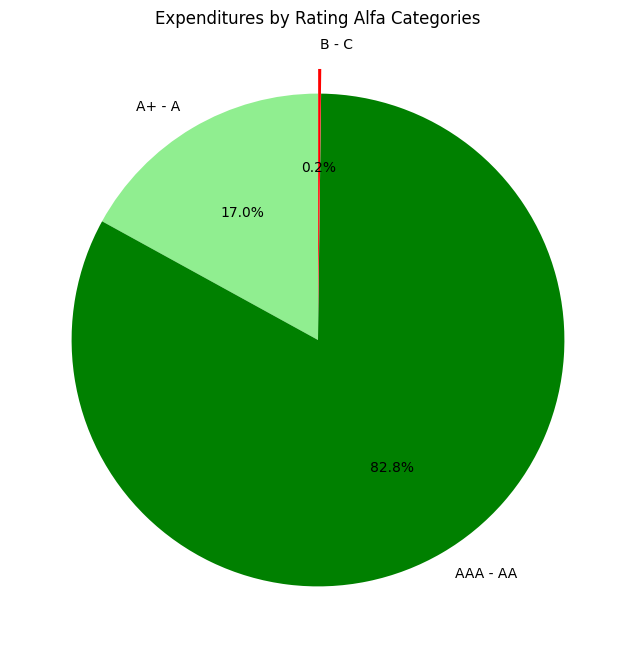

ei ole yhtään yritystä, jolla olisi sekä vastuullisuusmerkintä että huonoin luottamuusluokka (B-C)

### Miltä näyttävät "ongelmalliset" toimittajat taloudellisten kriterien perusteella?

#### Alle 2 % keskiliikevaihdosta

```
Median of 'Liikevaihto tuhat €': 237603.0
Mean of 'Liikevaihto tuhat €': 323045.2
```

|  | toimittaja_nimi | Liikevaihto tuhat € | % of Mean | % of Median |
| --- | --- | --- | --- | --- |
| 250 | Ginola Oy | 4682.0 | 1.45 | 1.97 |
| 674 | Aarni Rehab Oy | 1054.0 | 0.33 | 0.44 |
| 492 | Saarni Learning Oy | 1041.0 | 0.32 | 0.44 |
| 4326 | Falck Global Assistance Oy | 780.0 | 0.24 | 0.33 |
| 3381 | Jönssi Oy | 551.0 | 0.17 | 0.23 |
| 3356 | Ideapata Oy | 478.0 | 0.15 | 0.20 |
| 2963 | Voimala 1889 Oy | 380.0 | 0.12 | 0.16 |
| 5552 | Siteimprove Oy | 298.0 | 0.09 | 0.13 |
| 5589 | Sähkömestari Frisk Oy | 95.0 | 0.03 | 0.04 |
| 5408 | Wun-der-kid Oy | 18.0 | 0.01 | 0.01 |
| 2488 | Vienan Portti Oy | 9.0 | 0.00 | 0.00 |
| 792 | Poolmax Oy | NaN | NaN | NaN |
| 2172 | Kukkapii Oy | NaN | NaN | NaN |
| 2328 | Puheena Oy | NaN | NaN | NaN |
| 2580 | Eventum Lahti Oy | NaN | NaN | NaN |
| 3345 | Addiktum koulutus Oy | NaN | NaN | NaN |
| 3729 | Da-Service Ky | NaN | NaN | NaN |
| 3815 | VM Peat avoin yhtiö | NaN | NaN | NaN |
| 4375 | Sotkunen Kellari Oy | NaN | NaN | NaN |
| 4456 | Saariston Marjamaa Oy | NaN | NaN | NaN |
| 5387 | Stadin Night Oy | NaN | NaN | NaN |

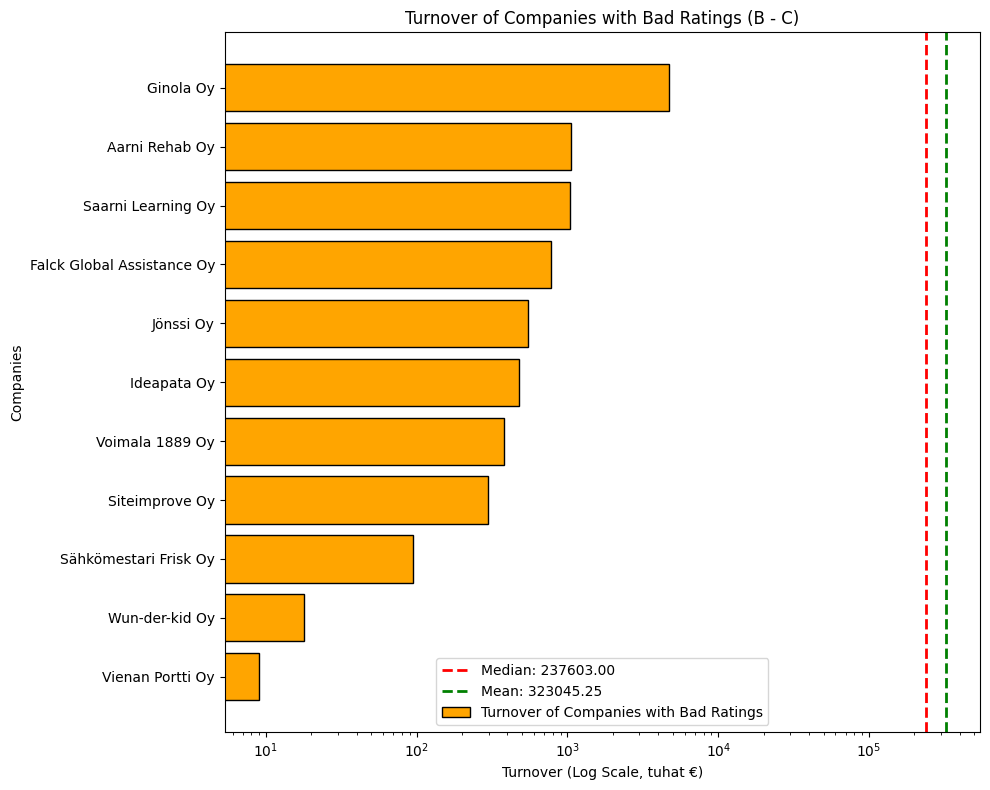

#### Hankintojen summat liikevoittoihin verrattuna

|  | toimittaja_nimi | tiliointisumma tuhat € | Liikevoitto tuhat € |
| --- | --- | --- | --- |
| 13 | VM Peat avoin yhtiö | 60766.20 |  |
| 19 | Siteimprove Oy | 17838.13 | 45.0 |
| 7 | Eventum Lahti Oy | 4462.00 |  |
| 20 | Sähkömestari Frisk Oy | 4269.39 |  |
| 0 | Ginola Oy | 3810.97 | 72.0 |
| 8 | Voimala 1889 Oy | 2409.64 |  |
| 15 | Sotkunen Kellari Oy | 2030.99 |  |
| 18 | Wun-der-kid Oy | 1995.00 |  |
| 11 | Jönssi Oy | 1900.00 | 41.0 |
| 3 | Poolmax Oy | 1648.70 |  |
| 16 | Saariston Marjamaa Oy | 1558.80 |  |
| 14 | Falck Global Assistance Oy | 1357.00 |  |
| 2 | Aarni Rehab Oy | 956.18 |  |
| 5 | Puheena Oy | 546.00 |  |
| 1 | Saarni Learning Oy | 500.00 |  |
| 12 | Da-Service Ky | 464.00 |  |
| 9 | Addiktum koulutus Oy | 399.00 |  |
| 6 | Vienan Portti Oy | 356.36 | 4.0 |
| 17 | Stadin Night Oy | 166.66 | 254.0 |
| 10 | Ideapata Oy | 72.80 |  |
| 4 | Kukkapii Oy | 31.87 |  |

#### Hankintojen summat bruttotuloksiin verrattuna

|  | toimittaja_nimi | tiliointisumma tuhat € | Bruttotulos tuhat € |
| --- | --- | --- | --- |
| 13 | VM Peat avoin yhtiö | 60766.20 |  |
| 19 | Siteimprove Oy | 17838.13 | 298.0 |
| 7 | Eventum Lahti Oy | 4462.00 |  |
| 20 | Sähkömestari Frisk Oy | 4269.39 | 171.0 |
| 0 | Ginola Oy | 3810.97 |  |
| 8 | Voimala 1889 Oy | 2409.64 | 144.0 |
| 15 | Sotkunen Kellari Oy | 2030.99 |  |
| 18 | Wun-der-kid Oy | 1995.00 | 19.0 |
| 11 | Jönssi Oy | 1900.00 | 458.0 |
| 3 | Poolmax Oy | 1648.70 |  |
| 16 | Saariston Marjamaa Oy | 1558.80 |  |
| 14 | Falck Global Assistance Oy | 1357.00 | 689.0 |
| 2 | Aarni Rehab Oy | 956.18 | 938.0 |
| 5 | Puheena Oy | 546.00 |  |
| 1 | Saarni Learning Oy | 500.00 | 863.0 |
| 12 | Da-Service Ky | 464.00 |  |
| 9 | Addiktum koulutus Oy | 399.00 |  |
| 6 | Vienan Portti Oy | 356.36 | 11.0 |
| 17 | Stadin Night Oy | 166.66 |  |
| 10 | Ideapata Oy | 72.80 | 378.0 |
| 4 | Kukkapii Oy | 31.87 | 180.0 |

#### Hankintojen summat omavaraisuuksiin verrattuna

|  | toimittaja_nimi | tiliointisumma tuhat € | Omavaraisuus |
| --- | --- | --- | --- |
| 13 | VM Peat avoin yhtiö | 60766.20 |  |
| 19 | Siteimprove Oy | 17838.13 | 20.0 |
| 7 | Eventum Lahti Oy | 4462.00 |  |
| 20 | Sähkömestari Frisk Oy | 4269.39 | -28.6 |
| 0 | Ginola Oy | 3810.97 | -49.2 |
| 8 | Voimala 1889 Oy | 2409.64 | -115.0 |
| 15 | Sotkunen Kellari Oy | 2030.99 |  |
| 18 | Wun-der-kid Oy | 1995.00 | -200.0 |
| 11 | Jönssi Oy | 1900.00 | 51.2 |
| 3 | Poolmax Oy | 1648.70 | 65.0 |
| 16 | Saariston Marjamaa Oy | 1558.80 |  |
| 14 | Falck Global Assistance Oy | 1357.00 | -28.2 |
| 2 | Aarni Rehab Oy | 956.18 | -129.2 |
| 5 | Puheena Oy | 546.00 | -4977.6 |
| 1 | Saarni Learning Oy | 500.00 | -5.9 |
| 12 | Da-Service Ky | 464.00 |  |
| 9 | Addiktum koulutus Oy | 399.00 |  |
| 6 | Vienan Portti Oy | 356.36 | -31.0 |
| 17 | Stadin Night Oy | 166.66 | 29.6 |
| 10 | Ideapata Oy | 72.80 | -66.7 |
| 4 | Kukkapii Oy | 31.87 | -201.5 |

#### Hankintojen summat liikevaihtoon verrattuna

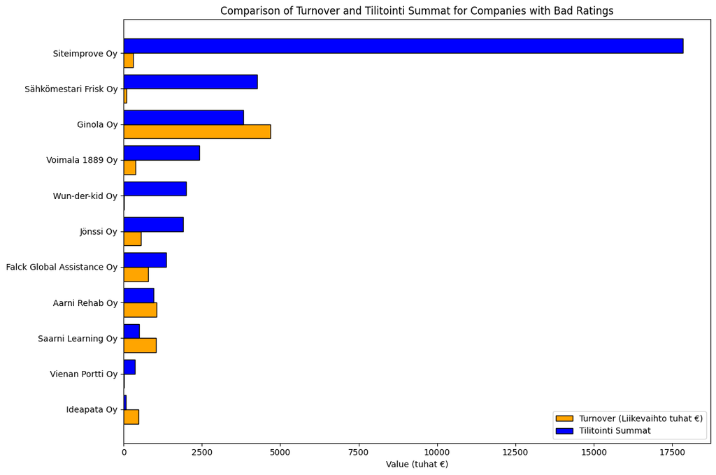